# Reproducible Data Analysis using R

Part 1: Basics

##### **Before We Begin - A Note on Reproducible Reports**

This document is written in *R Markdown*, a document creation tool that lets you combine formatted text and images with the code you write and the output your code generates. Blogs, journal articles, books, etc. often show descriptive analyses and visualisation of tabular data. In many cases, these analyses and plots are produced in R. Then one would wonder if the R code and the article/blog could be authored together rather than stitching up separately made pieces. The answer is yes, and R markdown could be used for exactly that. To make the idea more concrete, consider [this article](https://fivethirtyeight.com/features/the-pay-gap-is-way-too-entrenched-to-be-solved-by-women-alone/) on the website fivethirtyeight.com. They have obviously done quite a bit of exploratory data analysis and compiled the output together with the text of the article. Similar output can be produced by authoring the whole thing in markdown. The added advantage is that the reader can fetch the source (the markdown document) of the article, view and run the complete source code, reproduce and validate the results! Here are some examples that offer true reproducibility:

- Here is a blog post on [gender balance in maths](https://emitanaka.github.io/r/posts/2019-01-20-the-gender-balance-in-mathematical-sciences-a-case-study/). This entire post was written as R markdown, and [the Rmd file is available on the author’s github](https://github.com/emitanaka/r/blob/master/_posts/2019-01-20-the-gender-balance-in-mathematical-sciences-a-case-study/the-gender-balance-in-mathematical-sciences-a-case-study.Rmd).
- Here is a paper on [Spatial modelling of the two-party preferred vote in Australian federal elections](https://github.com/jforbes14/eechidna-paper/raw/master/elections.pdf). The whole thing was written as an R markdown file, and it is available on the [github page of one of the authors](https://github.com/jforbes14/eechidna-paper/blob/master/elections.Rmd).
- This one is a more lighthearted [blog post](https://livefreeordichotomize.com/2018/06/27/bringing-the-family-together-finding-the-center-of-geographic-points-in-r/), again written in R markdown. The source is available [here](https://github.com/LFOD/real-blog/blob/master/content/post/2018-06-27-bringing-the-family-together-finding-the-center-of-geographic-points-in-r.Rmd).

To know more about creating websites using R markdown, read [this post](https://livefreeordichotomize.com/2017/08/08/how-to-make-an-rmarkdown-website/). If you want to create more formal-looking academic articles, [this](https://elifesciences.org/labs/cad57bcf/composing-reproducible-manuscripts-using-r-markdown) may be helpful. For a detailed account on R markdown, see [R Markdown, The Definitive Guide](https://bookdown.org/yihui/rmarkdown/). If you’re in a hurry, [this cheat sheet](https://www.rstudio.com/wp-content/uploads/2016/03/rmarkdown-cheatsheet-2.0.pdf) will give you the essentials!

## The S Legacy

The predecessor of R is the S programming language that originated in the 1970’s at Bell Laboratories. R is almost an open source reimplementation of S, and the below books on S are often referred to as guides for the underlying principles and approaches.

**The Blue Book, The White Book and the Green Book**

[figure not shown]

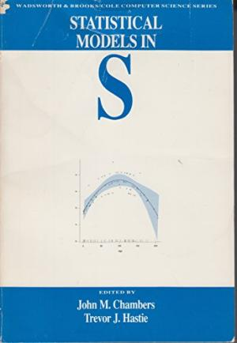

[figure not shown]

R was initially developed by two statisticians, Robert Gentleman and Ross Ihaka in the 1990’s at the University of Auckland. Their 1996 paper announcing R is [here](http://srv2.lemig.umontreal.ca/donnees/geo1512/IHAKA_JCGS_1996_R_concepts_implementation.pdf). R was open sourced under [GPL](https://en.wikipedia.org/wiki/GNU_General_Public_License), and got adopted by an active community of developers. Over the years R gained so much popularity that by late 2000’s, mainstream media started noticing:

[figure not shown]

## Gazillion Packages

What makes R so useful is the huge number of contributed packages for a wide range of things. Most of these packages are hosted on the [*The Comprehensive R Archive Network*](https://cran.r-project.org/) (CRAN). A smaller, but increasing number of packages are on Github and [Bioconductor](https://www.bioconductor.org/).

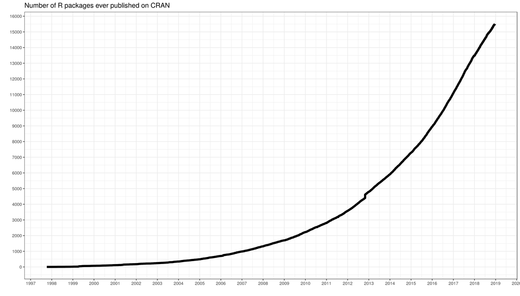

> (Source: https://gist.github.com/daroczig/3cf06d6db4be2bbe3368)

These directories may be helpful to find the packages you need:

- [CRAN Task Views](https://cran.r-project.org/web/views/)
- [An ‘awesome’ list for R](https://github.com/qinwf/awesome-R)

## R as a calculator

An expression can use operators and functions.

```r
2 * (31 - 10)
```

```
## [1] 42
```

```r
9^3 + 10^3
```

```
## [1] 1729
```

```r
1 / factorial(0) +
  1 / factorial(1) +
  1 / factorial(2) +
  1 / factorial(3) +
  1 / factorial(4) +
  1 / factorial(5)
```

```
## [1] 2.716667
```

```r
10000 * (1 + 0.08)^10
```

```
## [1] 21589.25
```

```r
log(2019)
```

```
## [1] 7.610358
```

```r
log(2019, 10) # The second argument is optional
```

```
## [1] 3.305136
```

```r
log10(2019)
```

```
## [1] 3.305136
```

```r
exp(log(2019))
```

```
## [1] 2019
```

```r
# integer division
102 %/% 10
```

```
## [1] 10
```

```r
# modulus (remainder)
102 %% 10
```

```
## [1] 2
```

```r
round(sqrt(2019), 2)
```

```
## [1] 44.93
```

```r
sqrt(-2019 + 0i) # complex number
```

```
## [1] 0+44.93328i
```

The above code illustrates the basic arithmetic operations in R. Base R includes a large number of built-in functions like log. You can read the documentation of a function using the ? operator. E.g. type `?log` on the console. For a full list of functions, see https://stat.ethz.ch/R-manual/R-devel/library/base/html/00Index.html

## Named objects (Variables)

```r
initial <- 10000
rate <- 0.08
years <- 10

final <- initial * (1 + rate)^years

print(final)
```

```
## [1] 21589.25
```

## Conditionals

```r
1 == 1
```

```
## [1] TRUE
```

```r
1 == 1.001
```

```
## [1] FALSE
```

```r
1 < 1.001
```

```
## [1] TRUE
```

```r
if(final > 2 * initial) {
  print("Your money more than doubled!")
} else {
  print("Hmm, It could grow more.")
}
```

```
## [1] "Your money more than doubled!"
```

```r
i <- 10
if((i %% 2 == 0) & (i %% 3 == 0)) { # Logical operator AND
  print("Divisible by 6")
}

## Replace FALSE below with the appropriate conditional expression using the logical OR, |
if(FALSE) {
  print("Not divisible by 6")
}
```

## Loops

A quick example of a `for` loop:

```r
sum <- 0

for(i in 0:100) {
  sum <- sum + 1 / factorial(i)
}

sum
```

```
## [1] 2.718282
```

```r
exp(1)
```

```
## [1] 2.718282
```

## Vectors

Vectors are objects that contain one or more elements. The elements of a vector should all be of the same type (mode) - numerical, logical, character, etc. Vectors are probably the most common type of object in R.

```r
some_names <- c("Alice", "Bob", "Charlie")
ages <- c(22, 13, 38, 5, 26)
birth_years <- 2019 - ages # Vector operation
print(birth_years)
```

```
## [1] 1997 2006 1981 2014 1993
```

```r
misc <- c("India", 22.12, sum < 2) # Will be coerced
class(some_names)
```

```
## [1] "character"
```

```r
class(ages)
```

```
## [1] "numeric"
```

```r
class(misc)
```

```
## [1] "character"
```

```r
more_names <- c("Dan", "Elsa")
all_names <- c(some_names, more_names)
all_names
```

```
## [1] "Alice"   "Bob"     "Charlie" "Dan"     "Elsa"
```

`rep` and `seq` can be used to construct vectors.

```r
twos <- rep(2, 20)
twos
```

```
##  [1] 2 2 2 2 2 2 2 2 2 2 2 2 2 2 2 2 2 2 2 2
```

```r
x <- 1:10
y <- seq(10, 1, -1) # same as 10:1
x + y
```

```
##  [1] 11 11 11 11 11 11 11 11 11 11
```

Indexing a vector (picking an item in a vector)

```r
print(c(x[1], x[10], y[1], y[10]))
```

```
## [1]  1 10 10  1
```

```r
x[-1] # drop the item at the index
```

```
## [1]  2  3  4  5  6  7  8  9 10
```

```r
x[1:5] + y[6:10]
```

```
## [1] 6 6 6 6 6
```

```r
ages > 18
```

```
## [1]  TRUE FALSE  TRUE FALSE  TRUE
```

```r
which(ages > 18)
```

```
## [1] 1 3 5
```

```r
all_names[ages > 18] # index by logical vector
```

```
## [1] "Alice"   "Charlie" "Elsa"
```

```r
all_names[which(ages > 18)] # index by a vector of indices
```

```
## [1] "Alice"   "Charlie" "Elsa"
```

You can name the elements in the vector

```r
names(x)
```

[output not shown]

```r
names(x) <- letters[1:length(x)]
names(x)
```

```
##  [1] "a" "b" "c" "d" "e" "f" "g" "h" "i" "j"
```

```r
x
```

```
##  a  b  c  d  e  f  g  h  i  j
##  1  2  3  4  5  6  7  8  9 10
```

```r
x[c('g', 'i')] # index by name
```

```
## g i
## 7 9
```

Missing values (NA) and NaN

```r
x <- c(2, 4, 0, NA, 10)
y <- c(1, 2, 0, 10, 1)
z <- x / y
is.na(z)
```

```
## [1] FALSE FALSE  TRUE  TRUE FALSE
```

```r
is.nan(z)
```

```
## [1] FALSE FALSE  TRUE FALSE FALSE
```

**Exercise**: try the functions `mode()`, `class()`, `str()`, `is.numeric()`, `is.logical()` and `length()` on your objects.

```r
## Complete this
```

Matrices and arrays in R are generalisations of vectors. We will skip them for now and introduce them when we encounter them later. They are rarely required if you are dealing with tabular data.

## Factors

Factors are a way of representing categorical data in R. Factors can take only one of the predefined values called levels. Factors can be defined as ordered or unordered, depending on whether the data has a natural order relevant to the problem at hand.

```r
days <- factor(c("Mon", "Mon", "Thu", "Tue"),
               levels = c("Sun", "Mon", "Tue", "Wed", "Thu", "Fri", "Sat"),
               ordered = TRUE)

days[3]
```

```
## [1] Thu
## Levels: Sun < Mon < Tue < Wed < Thu < Fri < Sat
```

## Lists

Lists are the most flexible type of objects in R. Lists can contain just about any type of objects, including lists. They could also be sometimes complex to manipulate. Use lists only when you need them.

```r
a <- list(name = "Alice", age = 11, height = 110)
str(a)
```

```
## List of 3
##  $ name  : chr "Alice"
##  $ age   : num 11
##  $ height: num 110
```

```r
a$age
```

```
## [1] 11
```

```r
a[[2]]
```

```
## [1] 11
```

**`[]` vs `[[]]` while indexing a list**

```r
a[2]
```

```
## $age
## [1] 11
```

```r
class(a$age)
```

```
## [1] "numeric"
```

```r
class(a[2])
```

```
## [1] "list"
```

```r
class(a[[2]])
```

```
## [1] "numeric"
```

`[[]]` gives you the item (component) at the index specified, while `[]` returns the sub-list matching the indexing criterion.

## Data Frames

Data frames can be thought of as lists of atomic vectors all having the same length. A data frame represents a table arranged in rows and columns.

```r
students <- list(name = c('Alice', 'Bob', 'Charlie'),
                age = c(11, 10, 11),
                status = factor(c("P", "A", "P")))

students
```

```
## $name
## [1] "Alice"   "Bob"     "Charlie"
##
## $age
## [1] 11 10 11
##
## $status
## [1] P A P
## Levels: A P
```

```r
students_df <- as.data.frame(students)

students_df
```

```
##      name age status
## 1   Alice  11      P
## 2     Bob  10      A
## 3 Charlie  11      P
```

```r
str(students_df)
```

```
## 'data.frame':    3 obs. of  3 variables:
##  $ name  : Factor w/ 3 levels "Alice","Bob",..: 1 2 3
##  $ age   : num  11 10 11
##  $ status: Factor w/ 2 levels "A","P": 2 1 2
```

## Functions

```r
calculate_interest <- function(p, r, n) {
  # complete this
}

final <- calculate_interest(initial, rate, years)

final
```

## Practice

1. What is happening here? Add appropriate spaces and parentheses to make it readable (and make sure you never write anything like this!):

```r
1:10-1-1:(11-1)
```

```
##  [1] -1 -1 -1 -1 -1 -1 -1 -1 -1 -1
```

2. Generate a vector containing the Fibonacci series, 1 1 2 3 5 8 13 21

```r
fib_series <- function(n) {
  ## Complete this
}

## Complete this
```

## Reference

- https://cran.r-project.org/doc/manuals/r-release/R-intro.pdf
- [The Base-R cheat sheet](https://www.rstudio.com/wp-content/uploads/2016/10/r-cheat-sheet-3.pdf)
- https://stat545.com/block004_basic-r-objects.html